# hw4

Iden Watanabe

March 14, 2018

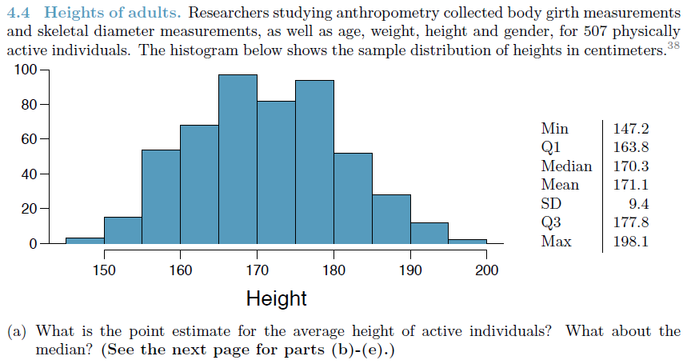

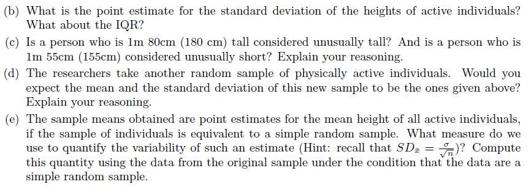

1. The sample mean is another word for the *point estimate*. In this case it is 171.1. The median is 170.3.
2. The standard deviation is 9.4. The IQR is `177.8 - 163.8 = 14`, or `184.3 - 156.3`.
3. A height of 180cm is within 1 standard deviation of the sample mean (`171.1 + 9.4 = 180.5`), so it’s not unusally tall. On the other hand, a height of 155cm falls within 2 standard deviations of the mean, so yes, I would consider it to be unusually short.
4. I would not expect it to be exact, but close. With many more sample means and standard deviations, it’ll grow closer to the population, and that would only occur if the values were relatively close.
5. We’re looking for the *standard error* of the sample, I believe. So we’ll use $SE = \frac{s}{\sqrt n}$, where `s` is the standard deviation of the sample and `n` is 507.

```r
se <- 9.4 / sqrt(507)
se
```

```
## [1] 0.4174687
```

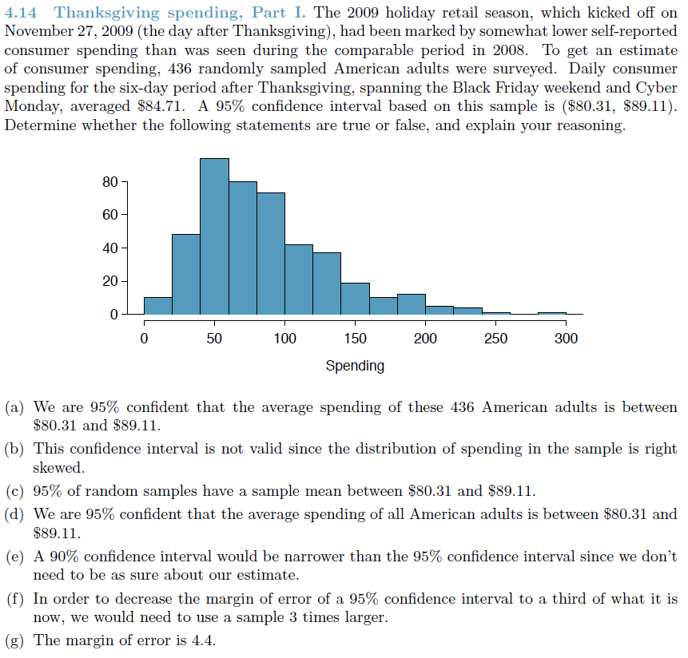

1. I’d say this is false. We can very easily calculate the mean of the sample (436 American adults). The purpose of a confidence interval is to extend the sample to the population. So we could say with 95% confidence that the average American shopper spent between $80.31 and $89.11.
2. I believe this is true, as the *Central Limit Theorem* states “If a sample consists of at least 30 independent observations and the data *are not strongly skewed*, then the distribution of the sample mean is well approximated by a normal model.” The data *is* strongly skewed, so the interval for a normal distribution isn’t valid, even though n > 30 (in fact n is > 100, so I’m not entirely sure here).
3. No, 95% of random samples would contain the actual mean. The sample means would help craft the interval.
4. True, as it’s the correct version of a.
5. It’s not narrower because we don’t need to be as sure, but narrower because we’re looking at less standard deviations from the mean, so I’d say this is false.
6. I’m not sure if a sample 3 times larger would decrease the margin of error by a third, but I know that increasing the sample size in general will decrease the margin of error, so I’ll just say this is true.
7. The book defines the *margin of error* as $z^* \times SE$. The SE, as we know from `4.4` is the sample $\frac{s}{\sqrt n}$, but it’s not given in this question. We can calculate it, however, since we know it’s needed for the confidence interval $84.71 \pm 1.96 \times SE$. Using just the positive interval, we can calculate the SE $89.11 = 84.71 + 1.96 \times SE$ or $\frac{4.4}{1.96} = SE$. From there, we can solve for the *margin of error*.

```r
se <- 4.4/1.96
1.96 * se
```

```
## [1] 4.4
```

So, yes, 4.4 is the margin of error.

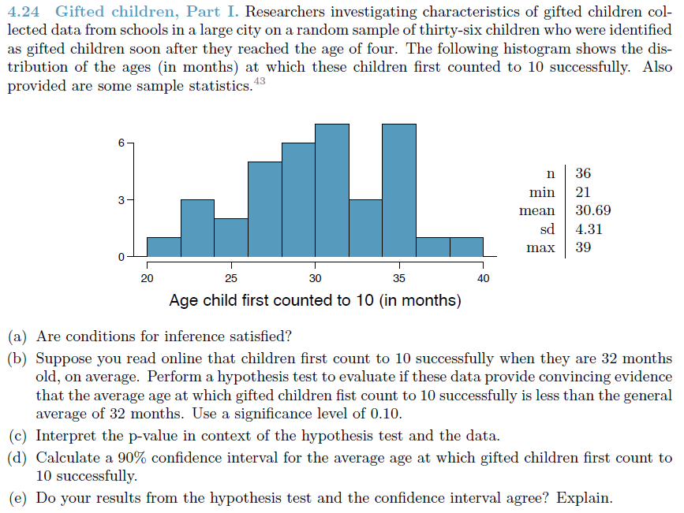

1. Yes, the sample is greater than 30 (36 in this case), and the distribution is not heavily skewed, although one must ask if “a large city” is enough of a representation.
2. Our null hypothesis is $H_0: \mu = 32$, and we’d like to show that gifted children do better than the average or our alternative is $H_A: \mu_{gifted}< 32$. The significance level is $\alpha = 0.10$
3. To find the p-value, we need to find the Z score $Z = \frac{\overline{x} - null}{SE_{\overline{x}}}$.

```r
z <- (30.69 - 32) / 4.31
pnorm(z)
```

```
## [1] 0.3805852
```

The p-value of 0.38 is much greater than the significance level of 0.10, so we are unable to reject the null hypothesis.

```r
se <- 4.31 / sqrt(36)
lowerlimit <- 30.69 - 1.65 * se
upperlimit <- 30.69 + 1.65 * se
c(lowerlimit, upperlimit)
```

```
## [1] 29.50475 31.87525
```

5. No, the hypothesis test showed the p-value being higher than the significance level, but the confidence interval shows that a mean of 32 would fall outside the confidence interval of gifted children, even accounting for the significance level. That would *seem* to show that gifted children do, on average, count to 10 faster.

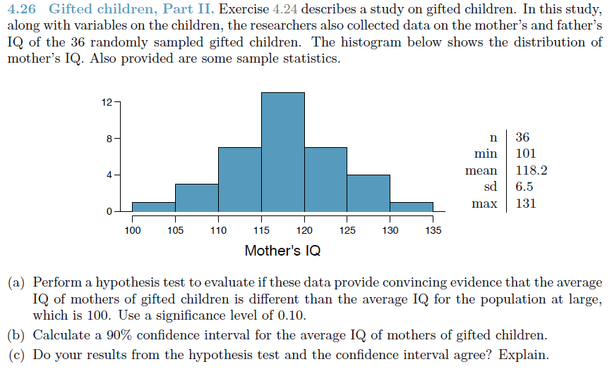

1. $H_0: \mu = 100$, $H_A: \mu > 100$, $\alpha = 0.10$

```r
z <- (118.2 - 100) / 6.5
pnorm(z)
```

```
## [1] 0.9974449
```

```r
1 - pnorm(z)
```

```
## [1] 0.00255513
```

We reject the null hypothesis, because the p-value is significantly smaller than the $\alpha$ value of 0.10. SO yes, the average IQ of mothers of gifted children is higher than the average IQ for the population.

```r
se <- 6.5 / sqrt(36)
lowerlimit <- 118.2 - 1.65 * se
upperlimit <- 118.2 + 1.65 * se
c(lowerlimit, upperlimit)
```

```
## [1] 116.4125 119.9875
```

3. Yes, assuming the mean IQ for the general population is correct, it falls well outside the 90% confidence interval for the sample.

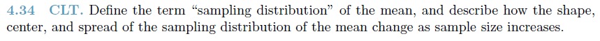

The sampling distribution is the distribution of the mean from a bunch of samples. As the sample size approaches 30, the distribution becomes more normal. As the sample size increases beyond this, the spread reduces over the center, even for very skewed data.

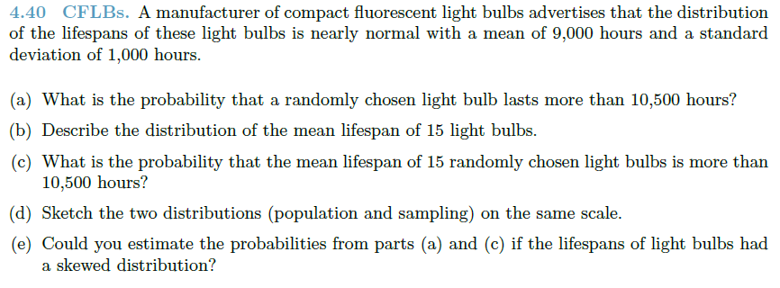

1. We can calculate this via Z score.

```r
z <- (10500 - 9000) / 1000
1 - pnorm(z)
```

```
## [1] 0.0668072
```

Only a 0.07 chance.

2. Given that the distribution of the population is already described as “nearly normal”, the sample of 15 should also be normal, although as it’s a small sample (< 30), we might expect to see some skew.
3. We don’t have a SD for the sample, so we’ll have to use the one for the population to calculate our SE.

```r
se <- 1000 / sqrt(15)
z = (10500 - 9000) / se
1 - pnorm(z)
```

```
## [1] 3.133452e-09
```

A very, very small chance. So small, it’s practically impossible.

```r
library(DATA606)
```

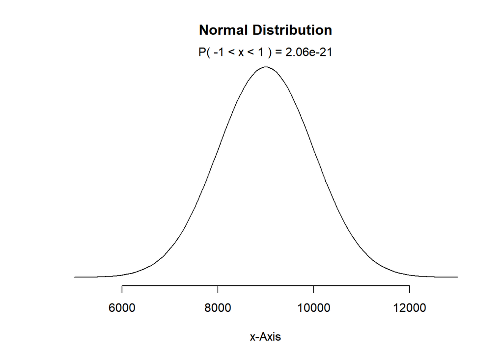

```r
normalPlot(mean = 9000, sd = 1000)
```

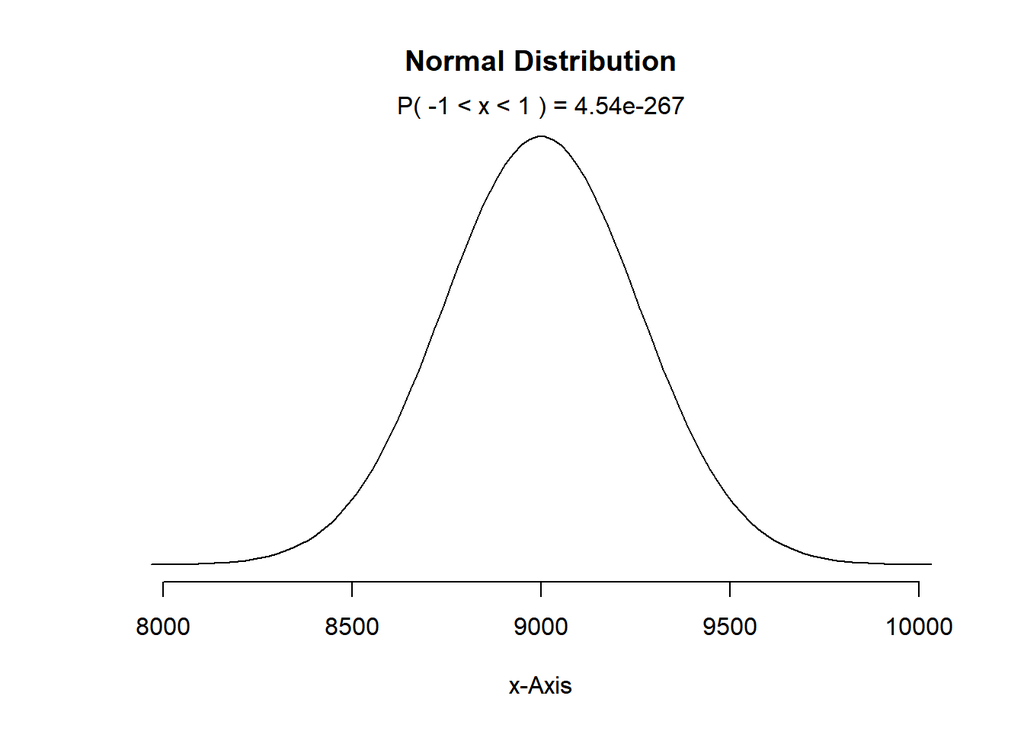

```r
normalPlot(mean = 9000, sd = se)
```

5. No to part a, as the Z score is dependent on a normal distribution. However, if our sample size was sufficiently large enough, then yes.

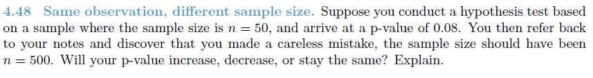

As the point estimates become more precise as the sample size increases, and the hypothetical already has such a low p-value of 0.08, I can only conclude that the p-value would decrease with a sample size 10 times that of the original calculation.